# NLP_Project_Sentiment_Analysis_Tiffany_Chan

Tiffany Chan

Natural Language Processing Project

Sentiment Analysis Classification of Twitter Airline Tweets

### 1. Import the libraries, load dataset, print shape of data, data description (5 Marks).

```python
#Importing necessary libraries.

import pandas as pd
from bs4 import BeautifulSoup
import re
#lower_case = letters_only.lower()
from nltk.corpus import stopwords
from sklearn.feature_extraction.text import CountVectorizer
from sklearn.feature_extraction.text import TfidfVectorizer
import numpy as np
from sklearn.ensemble import RandomForestClassifier
from sklearn.linear_model import LogisticRegression
from sklearn.tree import DecisionTreeClassifier
from sklearn.ensemble import BaggingClassifier
from sklearn.ensemble import AdaBoostClassifier
from sklearn.ensemble import GradientBoostingClassifier
from sklearn.neighbors import KNeighborsClassifier
from sklearn.naive_bayes import MultinomialNB
from sklearn.naive_bayes import GaussianNB
from sklearn import svm
from sklearn.model_selection import cross_val_score
import numpy as np
import pandas as pd

import nltk
nltk.download('punkt')
import contractions
import spacy
nlp = spacy.load('en_core_web_sm')
from sklearn.feature_extraction.text import CountVectorizer
from sklearn.model_selection import train_test_split

import matplotlib.pyplot as plt
import seaborn as sns
from sklearn.metrics import confusion_matrix
from sklearn.model_selection import RandomizedSearchCV
from scipy.stats import randint as sp_randint
```

```python
#Load dataset
#Read csv file
tweet = pd.read_csv('Tweets.csv')
```

```python
#Shape of data. Data dimensions
tweet.shape
```

```
(14640, 15)
```

#### There are 14640 rows (tweets to analyze), and 15 columns (features).

```python
#Descriptive statistics (Data description)
tweet.describe
```

```
<bound method NDFrame.describe of                  tweet_id airline_sentiment  airline_sentiment_confidence  \
0      570306133677760513           neutral                        1.0000
1      570301130888122368          positive                        0.3486
2      570301083672813571           neutral                        0.6837
3      570301031407624196          negative                        1.0000
4      570300817074462722          negative                        1.0000
...                   ...               ...                           ...
14635  569587686496825344          positive                        0.3487
14636  569587371693355008          negative                        1.0000
14637  569587242672398336           neutral                        1.0000
14638  569587188687634433          negative                        1.0000
14639  569587140490866689           neutral                        0.6771

               negativereason  negativereason_confidence         airline  \
0                         NaN                        NaN  Virgin America
```

[output cut: 64 more lines]

Most of these features aren't really pertinent to this project. So, it is important to limit it to the 'text' and 'airline_sentiment'.

```python
#Looking at the nature of each variable to see if we would need to change their status later.
tweet.dtype
```

```
tweet_id                          int64
airline_sentiment                object
airline_sentiment_confidence    float64
negativereason                   object
negativereason_confidence       float64
airline                          object
airline_sentiment_gold           object
name                             object
negativereason_gold              object
retweet_count                     int64
text                             object
tweet_coord                      object
tweet_created                    object
tweet_location                   object
user_timezone                    object
dtype: object
```

Technically, we will only need to look at the 'text' and 'airline_sentiment' features. They are both listed as objects here. We may need to convert 'text' to string later.

```python
#Let's look at the frequency of tweet sentiments.
tweet['airline_sentiment'].value_counts()
```

```
negative    9178
neutral     3099
positive    2363
Name: airline_sentiment, dtype: int64
```

### 2. Understand of data-columns (5 Marks):

### a. Drop all other columns except “text” and “airline_sentiment”.

### b. Check the shape of data.

### c. Print first 5 rows of data.

```python
# a. Drop all other columns except “text” and “airline_sentiment”.
tweet2 = tweet[['text', 'airline_sentiment']]
```

```python
# b. Check the shape of data.
tweet2.shape
```

```
(14640, 2)
```

```python
# c. Print first 5 rows of data.
tweet2.head()
```

|  | text | airline_sentiment |
| --- | --- | --- |
| 0 | @VirginAmerica What @dhepburn said. | neutral |
| 1 | @VirginAmerica plus you've added commercials t... | positive |
| 2 | @VirginAmerica I didn't today... Must mean I n... | neutral |
| 3 | @VirginAmerica it's really aggressive to blast... | negative |
| 4 | @VirginAmerica and it's a really big bad thing... | negative |

You could see that even though text is in a dataframe. It is still considered unstructured data. We need to clean it up before we feed it into our ML models.

```python
#Let's use this tweet (#2040) as an example to verify that the pre-processing steps work.

print (tweet2["text"][2040])
```

```
@united oh, I'll be sharing alright. Especially about sleeping in this shitty airport and getting 1hr of sleep all night because UA.
```

### 3. Text pre-processing: Data preparation.(20Marks)

### a. Html tag removal.

### b. Tokenization.

### c. Remove the numbers.

### d. Removal of Special Characters and Punctuations.

### e. Conversion to lowercase.

### f. Lemmatize or stemming.

### g. Join the words in the list to convert back to text string in the dataframe. (So that each row contains the data in text format.)

### h. Print first 5 rows of data after pre-processing.

```python
# 3a. Html tag removal
# We should run this in the odd chance that there is a html tag in the text column

def strip_html(text):
    soup = BeautifulSoup(text, "html.parser")
    return soup.get_text()

tweet2['text'] = tweet2['text'].apply(lambda x: strip_html(x))
tweet2.head()
```

|  | text | airline_sentiment |
| --- | --- | --- |
| 0 | @VirginAmerica What @dhepburn said. | neutral |
| 1 | @VirginAmerica plus you've added commercials t... | positive |
| 2 | @VirginAmerica I didn't today... Must mean I n... | neutral |
| 3 | @VirginAmerica it's really aggressive to blast... | negative |
| 4 | @VirginAmerica and it's a really big bad thing... | negative |

```python
# b. Tokenization

import nltk                            #Repeated here just in case

nltk.download('punkt')                 #Repeated here just in case



tweet2['text'] = tweet2.apply(lambda row: nltk.word_tokenize(row['text']), axis=1) # Tokenization of data
```

```python
# c. Remove the numbers

tweet2['text'] = tweet2['text'].astype(str)

def remove_numbers(text):
  text = re.sub(r'\d+', '', text)
  return text

tweet2['text'] = tweet2['text'].apply(lambda x: remove_numbers(x))
tweet2.head()
```

|  | text | airline_sentiment |
| --- | --- | --- |
| 0 | ['@', 'VirginAmerica', 'What', '@', 'dhepburn'... | neutral |
| 1 | ['@', 'VirginAmerica', 'plus', 'you', "'ve", '... | positive |
| 2 | ['@', 'VirginAmerica', 'I', 'did', "n't", 'tod... | neutral |
| 3 | ['@', 'VirginAmerica', 'it', "'s", 'really', '... | negative |
| 4 | ['@', 'VirginAmerica', 'and', 'it', "'s", 'a',... | negative |

You can see from the data that Tokenization was successful because each word and symbol is surounded by their own set of quation marks and separated by commas.

```python
# d. Removal of special characters and punctuation.
# Remove contractions
import contractions
def replace_contractions(text):
    """Replace contractions in string of text"""
    return contractions.fix(text)

tweet2['text'] = tweet2['text'].apply(lambda x: replace_contractions(x))
tweet2.head()
```

|  | text | airline_sentiment |
| --- | --- | --- |
| 0 | ['@', 'VirginAmerica', 'What', '@', 'dhepburn'... | neutral |
| 1 | ['@', 'VirginAmerica', 'plus', 'you', "'ve", '... | positive |
| 2 | ['@', 'VirginAmerica', 'I', 'did', "n't", 'tod... | neutral |
| 3 | ['@', 'VirginAmerica', 'it', "'s", 'really', '... | negative |
| 4 | ['@', 'VirginAmerica', 'and', 'it', "'s", 'a',... | negative |

```python
print (tweet2["text"][2040])
```

```
['@', 'united', 'oh', ',', 'I', " will", 'be', 'sharing', 'alright', '.', 'Especially', 'about', 'sleeping', 'in', 'this', 'shitty', 'airport', 'and', 'getting', 'hr', 'of', 'sleep', ', 'night', 'because', 'UA', '.']
```

You can see that the contractions are now gone. "I'll" changed to "I will" in this tweet.

```python
# Remove special characters and punctuation
import re

def remove_special_characters(text, remove_digits=False):
    pattern = r'[^a-zA-Z0-9\s]' if not remove_digits else r'[^a-zA-Z\s]'
    text = re.sub(pattern, '', text)
    return text

tweet2['text'] = tweet2['text'].apply(lambda x: remove_special_characters(x))
tweet2.head()
```

|  | text | airline_sentiment |
| --- | --- | --- |
| 0 | VirginAmerica What dhepburn said | neutral |
| 1 | VirginAmerica plus you ve added commercials t... | positive |
| 2 | VirginAmerica I did nt today Must mean I nee... | neutral |
| 3 | VirginAmerica it s really aggressive to blast... | negative |
| 4 | VirginAmerica and it s a really big bad thing... | negative |

```python
print (tweet2["text"][2040])
```

```
 united oh  I  will be sharing alright  Especially about sleeping in this shitty airport and getting hr of sleep  night because UA
```

The ampersand (@) is now gone. We removed the special characters and the punctuation. There are no more commas or quotation marks that were left by Tokenization.

```python
# e. Conversion to lowercase
tweet2 = pd.DataFrame(tweet2)

tweet2['text'] = tweet2['text'].str.lower()
print (tweet2["text"][2040])
```

```
 united oh  i  will be sharing alright  especially about sleeping in this shitty airport and getting hr of sleep  night because ua
```

This is important because we don't want capitalization to hinder our ability to identify the same words.

```python
# f. Stemming or Lemmatization
#Since we are going to explore stemming and lemmatization, let's make copies of the dataframe so that we don't get confused

tweet_stem = tweet2
tweet_lemma = tweet2
```

```python
#Checking to see if the dataframe was copied correctly
print (tweet_stem["text"][2040])
```

```
 united oh  i  will be sharing alright  especially about sleeping in this shitty airport and getting hr of sleep  night because ua
```

```python
#Let's do stemming first
def simple_stemmer(text):
    ps = nltk.porter.PorterStemmer()
    text = ' '.join([ps.stem(word) for word in text.split()])
    return text

tweet_stem['text'] = tweet_stem['text'].apply(lambda x: simple_stemmer(x))
tweet_stem.head()
```

|  | text | airline_sentiment |
| --- | --- | --- |
| 0 | virginamerica what dhepburn said | neutral |
| 1 | virginamerica plu you ve ad commerci to the ex... | positive |
| 2 | virginamerica i did nt today must mean i need ... | neutral |
| 3 | virginamerica it s realli aggress to blast obn... | negative |
| 4 | virginamerica and it s a realli big bad thing ... | negative |

```python
#Code for lemmatization.
#This is just to be used as a comparison to CountVectorizer when we run models to see if there are any differences in results.

import spacy
nlp = spacy.load('en_core_web_sm')


def lemmatize_text(text):
    text = nlp(text)
    text = ' '.join([word.lemma_ if word.lemma_ != '-PRON-' else word.text for word in text])
    return text

#data_features = data_features.apply(lambda x: lemmatize_text(x))
#data_features.head()

tweet_lemma["text"] = tweet_lemma["text"].apply(lemmatize_text)
```

```python
tweet_lemma.head()
```

|  | text | airline_sentiment |
| --- | --- | --- |
| 0 | virginamerica what dhepburn say | neutral |
| 1 | virginamerica plu you ve ad commerci to the ex... | positive |
| 2 | virginamerica I do nt today must mean I need t... | neutral |
| 3 | virginamerica it s realli aggress to blast obn... | negative |
| 4 | virginamerica and it s a realli big bad thing ... | negative |

You could tell that it lemmatization worked because in the first document, "say" replaced "said"

### 4. Vectorization (10 Marks):

### a. Use CountVectorizer.

### b. Use TfidfVectorizer.

```python
# 4a. CountVectorizer
# This is a way to convert unstructured data into structured data - Changing words into numbers for ML model evaluation.

from sklearn.feature_extraction.text import CountVectorizer

vectorizer = CountVectorizer(max_features=1000)                # Keep only the first 1000 most frequent features.

#Countvectorizer for stemming data
tweet_stem_vectoriz = vectorizer.fit_transform(tweet_stem['text'])
#Countvectorizer for lemmatization data
tweet_lemma_vectoriz = vectorizer.fit_transform(tweet_lemma['text'])
```

```python
# 4b. TF-IDF Vectorizer
# This is a way to convert unstructured data into structured data - Changing words into numbers for ML model evaluation.

#TF-IDF
from sklearn.feature_extraction.text import TfidfVectorizer


tfidfvectorizer = TfidfVectorizer(max_features=1000)

#TF-IDF vectorizer for stemming data
tweet_stem_tfidf = tfidfvectorizer.fit_transform(tweet_stem['text'])
#TF-IDF vectorizer for lemmatization data
tweet_lemma_tfidf = tfidfvectorizer.fit_transform(tweet_lemma['text'])
```

```python
#Transform all stemming/lemmatized and vectorized data into arrays


data_features_stem_vec = tweet_stem_vectoriz.toarray()        #Stemming-CountVectorized
data_features_lemma_vec = tweet_lemma_vectoriz.toarray()      #Lemmatization-CountVectorized
data_features_stem_tfidf = tweet_stem_tfidf.toarray()         #Stemming-TF-IDF
data_features_lemma_tfidf = tweet_lemma_tfidf.toarray()        #Lemmatization-TF-IDF
```

```python
#Checking to see if TF-IDF was successful

data_features_stem_tfidf[10]
```

[output not shown]

[output cut: 145 more lines]

[output not shown]

```python
#Checking to see if CountVectorizer was successful


data_features_stem_vec[10]
```

[output not shown]

[output cut: 31 more lines]

```python
#Create simpler name for the labels (outcome)
labels_stem = tweet_stem['airline_sentiment']
labels_lemma = tweet_lemma['airline_sentiment']
```

### 5. Fit and evaluate model using both type of vectorization.(6+6 Marks)

```python
#Split data into training and testing set for stemming/lemmatized/CountVectorized/TF-IDF data

from sklearn.model_selection import train_test_split


#Stemming-CountVectorizer Data
X_train_stem_vec, X_test_stem_vec, y_train_stem_vec, y_test_stem_vec = train_test_split(data_features_stem_vec, labels_stem, test_size=0.3, random_state=42)
#Lemmatization-CountVectorizer Data
X_train_lemma_vec, X_test_lemma_vec, y_train_lemma_vec, y_test_lemma_vec = train_test_split(data_features_lemma_vec, labels_lemma, test_size=0.3, random_state=42)
#Stemming- TF-IDF Data
X_train_stem_tfidf, X_test_stem_tfidf, y_train_stem_tfidf, y_test_stem_tfidf = train_test_split(data_features_stem_tfidf, labels_stem, test_size=0.3, random_state=42)
#Lemmatization-TF-IDF Data
X_train_lemma_tfidf, X_test_lemma_tfidf, y_train_lemma_tfidf, y_test_lemma_tfidf = train_test_split(data_features_lemma_tfidf, labels_lemma, test_size=0.3, random_state=42)
```

## Model of Choice:

### Logistic Regression Model #1: Using CountVectorizer

```python
#Logistic Regression using data that went through stemming and CountVectorization

from sklearn.linear_model import LogisticRegression                     # Importing logistic regression

lr = LogisticRegression()

lr_stem_vec= lr.fit(X_train_stem_vec, y_train_stem_vec)
```

```python
# Accuracy score after K-Fold Cross-validation on training set.
# Model's accuracy is based on the average of each fold.

lr_stem_vec_train = np.mean(cross_val_score(lr_stem_vec,X_train_stem_vec,y_train_stem_vec,cv=10))
lr_stem_vec_train
```

[output not shown]

[output cut: 25 more lines]

[output not shown]

```
0.7862981135670732
```

With K-Fold cross validation, model overfitting is less likely.

```python
#Test this first logistic regression model on the test data
lr_stem_vec_test = lr_stem_vec.score(X_test_stem_vec, y_test_stem_vec)
lr_stem_vec_test
```

```
0.8010018214936248
```

Strangely enough, the logistic regression model was strong when we tested it on the test data. It showed an 80% accuracy on the test data, one of the highest of all the models I created.

```python
#Get the model to make predictions.

lr_result_stem_vec = lr_stem_vec.predict(X_test_stem_vec)
lr_result_stem_vec
```

```
array(['positive', 'negative', 'negative', ..., 'negative', 'negative',
       'negative'], dtype=object)
```

```
[[2500  226   88]
 [ 263  539   82]
 [ 115  100  479]]
```

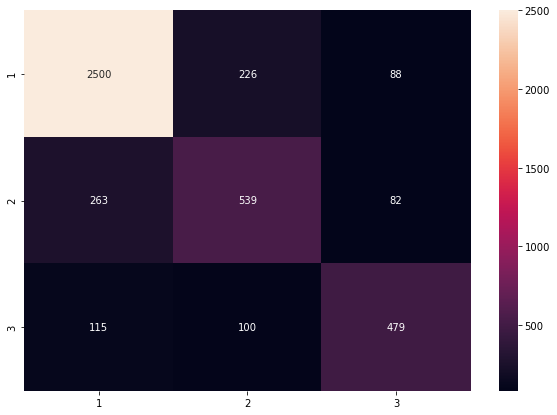

```python
#Let's create the confusion matrix fot this first logistic regression model.

import matplotlib.pyplot as plt
import seaborn as sns
from sklearn.metrics import confusion_matrix

conf_mat_lg1 = confusion_matrix(y_test_stem_vec, lr_result_stem_vec)

print(conf_mat_lg1)

df_cm = pd.DataFrame(conf_mat_lg1, index = [i for i in "123"],
                  columns = [i for i in "123"])
plt.figure(figsize = (10,7))
sns.heatmap(df_cm, annot=True, fmt='g')
```

Here, 1 = "Negative", 2 = "Neutral", and 3 = "Positive".

Columns = Predictions

Rows = Actual

From this model, 2500 tweets were correctly predicted as "negative", "539" were predicted as "neutral", and 479 were predicted as "positive", resulting in an 80% accuracy on unseen test data.

Let's discuss the precision and recall for all of the sentiment types:

Negative sentiment: Precision: 2500/(2500+263+115) = 0.87 (87%), Recall: 2500/(2500+226+88) = 0.89 (89%)

Neutral sentiment: Precision: 539/(226+539+100) = 0.62 (62%), Recall: 539/(263+539+82) = 0.61 (61%)

Positive sentiment: Precision: 479/(88+82+479) = 0.74 (74%), Recall: 479/(115+100+479) = 0.69 (69%)

In general, the logistic regression model performed very well in that it got 80% of the test data accurate.

When it comes to its predictions for each sentiment type, it performed extraordinarily well with negative sentiments. Of all the negative predictions, 87% were actually accurate. Recall for negative sentiment was even higher; of all the actual negative sentiments, 89% were predicted accurately. In detecting positive sentiments, logistic regression performed decently: 74% of all positive predictions were truly correct while 69% of true positive sentiments were predicted accurately.

The model faltered mostly in predicting neutral sentiments. Precision for neutral sentiments was only 62% and recall was even lower at 61%. This goes to show that the model is strong in predicting extreme sentiments but does not perform as well on messages that lie in the neutral zone.

### 2nd logistic regression Model: Using TF-IDF

```python
#Logistic Regression using TF-IDF data

lr = LogisticRegression()

lr_stem_tfidf= lr.fit(X_train_stem_tfidf, y_train_stem_tfidf)       #We will continue using the stemming data just for comparison to the previous model.
```

```python
#K-Fold cross validation accuracy score.
#Accuracy is the average of each fold's accuracy

lr_stem_tfidf_train = np.mean(cross_val_score(lr_stem_tfidf,X_train_stem_tfidf,y_train_stem_tfidf,cv=10))
lr_stem_tfidf_train
```

```
0.7933234565548781
```

The accuracy score for this second logistic regression model using TF-IDF data is only slightly higher than the first model. TF-IDF Vectorization method gives unique weights to word frequency, and is supposed to yield better results than CountVectorizer which holds the same weight for each word. So, this higher accuracy is not unexpected.

```python
#Test this 2nd logistic regression model (TF-IDF) on the test data
lr_stem_tfidf_test = lr_stem_tfidf.score(X_test_stem_tfidf, y_test_stem_tfidf)
lr_stem_tfidf_test
```

```
0.8085154826958105
```

As expected, there is a high accuracy (81%) with no real overfitting issues.

Both CountVectorizer and TF-IDF yielded very similar results on training and testing data for logistic regression. The TF-IDF dataset had a test accuracy of 81% while the CountVectorizer data had a test accuracy of 80%.

```python
#Let's look at the predictions with the TF-IDF Vectorized data:
lr_result_stem_tfidf = lr_stem_vec.predict(X_test_stem_tfidf)
lr_result_stem_tfidf
```

```
array(['positive', 'neutral', 'negative', ..., 'neutral', 'negative',
       'neutral'], dtype=object)
```

```
[[1320 1470   24]
 [  35  833   16]
 [  44  386  264]]
```

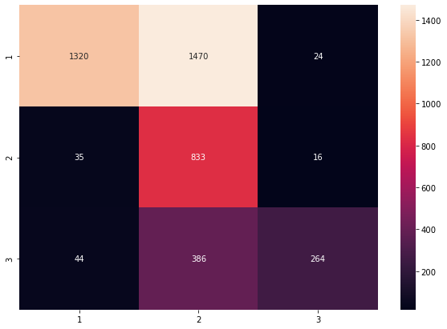

```python
#Let's look at the confusion matrix for the Stemming-TF-IDF Vectorized data.

import matplotlib.pyplot as plt
import seaborn as sns
from sklearn.metrics import confusion_matrix

conf_mat2 = confusion_matrix(y_test_stem_tfidf, lr_result_stem_tfidf)

print(conf_mat2)

df_cm2 = pd.DataFrame(conf_mat2, index = [i for i in "123"],
                  columns = [i for i in "123"])
plt.figure(figsize = (10,7))
sns.heatmap(df_cm2, annot=True, fmt='g')
```

Here, 1 = "Negative", 2 = "Neutral", and 3 = "Positive".

Columns = Predictions

Rows = Actual

Let's discuss the precision and recall for all of the sentiment types:

Negative sentiment: Precision: 1320/(1320+35+44) = 0.94 (94%), Recall: 1320/(1320+1470+24) = 0.47 (47%)

Neutral sentiment: Precision: 833/(1470+833+386) = 0.31 (31%), Recall: 833/(35+833+16) = 0.94 (94%)

Positive sentiment: Precision: 264/(24+16+264) = 0.87 (87%), Recall: 264/(44+386+264) = 0.38 (38%)

The opposite holds true for neutral sentiments, high recall (0.94(94%)) but very low precision (0.31(31%)). Among all the true neutral Tweets, this model predicted a high amount correctly. Of all the neutral predictions, only 31% were actually neutral.

##### Final comparison between both models:

The CountVectorizer model seemed to peform better than the TF-IDF model for logistic regression. The CountVectorizer model had recall and precision values that were all above 60%, which made it a lot more balanced and reliable. On the other hand, the TF-IDF delivered some very high metric scores but also very low metric scores as well.

If I had to deploy one of these models, I would choose the logistic regression-CountVectorizer model.

### 6. Summarize your understanding of the application of Various Pre-processing and Vectorization and performance of your model on this dataset. (8 Marks)

### Pre-Processing:

All the pre-processing steps are crucial. It's basically cleaning the data. These are steps data scientists use to reduce the amount of noise in the data and to disgard features or items that bear irrelevant meaning. These unnecessary features include: special characters like ampersand (@), punctuation like the comma (,), html text. It also groups important words together like 'GOOD', and 'good' by adopting lowercase letters, or grouping 'well' and 'good' using lemmatization. These are fundamental organizational steps to reduce the not so important dimensions.

The most notable pre-processing step that I can attest its value to the models are: stemming and lemmatization. They performed almost exactly the same for this data even though their functions are different. Stemming cuts off prefixes and suffixes to organize words based on similarity. Lemmatization has a backend dictionary that transforms words to their root words.

### Vectorization:

It is important to note that the CountVectorizer transforms text data into 0s and 1s, which can be interpreted as discrete values. On the other hand, TF-IDF scores words based on frequency and assigns float-like values to each word. Lesser weight is given to more frequent words and more weight is given to infrequent words. For the Naive Bayes models (Towards the end of the document), there is MultinomialNB() and there is GaussianNB(). MultinomialNB() works better with discrete values and Gaussian NB() works better with continuous numerical data. I used GaussianNB() on the TF-IDF X_train data, and the CountVectorizer data with MultinomialNB(). The MultinomialNB()-CountVectorizer model peformed a lot better with 78% accuracy compared to 37% accuracy for the GaussianNB()-TF-IDF model.

#### Model Performance:

I originally expected Naive Bayes or Support Vector Machine to be the top contenders for this project because when it comes to natural language processing, these models tend to perform very well (Neural networks also). For this project, SVM came close. Despite having the highest accuracy of all models, it bombed a lot more than logistic regression using CountVectorizer on other important classification metrics. It wasn't as reliable of a model (See Support Vector Machine Models 4 and 5 in Hyperparameter Tuning Section near the end of this document).

Logistic regression using CountVectorizer data seems to be my choice model of all the choices here. Support Vector Machine may be 2nd and Adaboost is 3rd. Despite it not having the absolute highest accuracy among all, logistic regression with CountVectorizer had decent recall scores, especially when it came to positive and neutral Tweets. Recall measure, in my opinion, is a more important metric to consider than accuracy in this instance because the classes are not balanced, with the majority of tweets in this dataset being negative in nature, 63% to be exact.

It is so important to consider 1-Recall especially because this indicates how many negative, neutral or positive Tweets your model missed. For my model of choice, recall for neutral tweets was: 61%, recall for positive tweets was: 69% and recall for negative tweets was: 89%. This means that the model will miss 39% of the neutral tweets, and 31% of the positive tweets, and 11% of the negative tweets. This is a lot better than the results from the second logistic regression model using TF-IDF, where it is expected to miss 53% of the negative tweets (recall: 47%), 6% of the neutral tweets (recall: 94%), and 62% of the positive tweets (recall: 38%). Improvement in recall and 1-recall makes a far better model even if I have to sacrifice 1% in accuracy.

```python
# Accuracy Table of all Machine Learning Models:
# Highest Train accuracy from K-Fold Cross Validation, and Highest Test Accuracy Recorded For Each Model Type

Accuracy_Table ={'ML Model':['Logistic Regression', 'Logistic Regression' , 'Support Vector Machine', 'Support Vector Machine', 'Random Forest', 'Decision Tree', 'Bagging', 'AdaBoost', 'Gradient Boost', 'K Nearest Neighbors', 'Naive Bayes'], 'Vectorization Method': ['CountVectorizer', 'TF-IDF', 'CountVectorizer', 'TF-IDF', 'CountVectorizer', 'CountVectorizer', 'CountVectorizer', 'CountVectorizer', 'CountVectorizer', 'TF-IDF', 'CountVectorizer'], 'Train_Accuracy':[lr_stem_vec_train, lr_stem_tfidf_train, svm_rbf_stem_vec_train, svm_rbf_stem_tfidf_train, forest_lemma_vec_train, dt_stem_vec_train, bag_stem_vec_train, abcl_stem_vec_train, gbcl_stem_vec_train, knc_stem_tfidf_train, mnb_stem_vec_train], 'Test_Accuracy':[lr_stem_vec_test, lr_stem_tfidf_test, svm_rbf_stem_vec_test, svm_rbf_stem_tfidf_test, forest_lemma_vec_test, dt_stem_vec_test, bag_stem_vec_test, abcl_stem_vec_test, gbcl_stem_vec_test, knc_stem_tfidf_test, mnb_stem_vec_test], 'Notes': ['Choice Model', 'High accuracy, low recall for positive and neutral Tweets', 'High accuracy, low recall for positive and neutral Tweets', 'High accuracy, low recall for positive and neutral tweets', '', '', '', '', '', '', ', ']}
Accuracy_Table_= pd.DataFrame(Accuracy_Table)
Accuracy_Table_
```

|  | ML Model | Vectorization Method | Train_Accuracy | Test_Accuracy | Notes |
| --- | --- | --- | --- | --- | --- |
| 0 | Logistic Regression | CountVectorizer | 0.786298 | 0.801002 | Choice Model |
| 1 | Logistic Regression | TF-IDF | 0.793323 | 0.808515 | High accuracy, low recall for positive and neu... |
| 2 | Support Vector Machine | CountVectorizer | 0.789326 | 0.811248 | High accuracy, low recall for positive and neu... |
| 3 | Support Vector Machine | TF-IDF | 0.794984 | 0.809882 | High accuracy, low recall for positive and neu... |
| 4 | Random Forest | CountVectorizer | 0.764050 | 0.782332 |  |
| 5 | Decision Tree | CountVectorizer | 0.698770 | 0.715847 |  |
| 6 | Bagging | CountVectorizer | 0.758683 | 0.773224 |  |
| 7 | AdaBoost | CountVectorizer | 0.765221 | 0.786202 |  |
| 8 | Gradient Boost | CountVectorizer | 0.756927 | 0.766621 |  |
| 9 | K Nearest Neighbors | TF-IDF | 0.720434 | 0.724954 |  |
| 10 | Naive Bayes | CountVectorizer | 0.772930 | 0.780282 | , |

## Ways to improve:

### 1. Downsampling the number of negative tweets.

Downsampling the number of negative tweets would lower the bias towards the larger class. This could improve model performance and better the precision and recall metrics.

### 2. Try a neural network model.

Neural networks have strong success when it comes to natural language processing. I would have tried it but there are different steps in the pre-processing. In neural networks, you need to prepare embeddings using applications like Word2vec, GloVe and fastText. The data has to be converted from sparse (like what we have here) to dense. In sparse data, there are excessive zeroes, like what we see in TF-IDF transformed data.

### 3. Implement a list of stopwords.

This could further help to diminish the amount of noise in textual data, and remove features that don't carry much meaning.

### 4. Create a mixed model.

Stacking and Blending are techniques that allow you to take advantage of the strengths of multiple model types like random forest, logistic regression, etc. For blending models, you can assign weights to each method and capitalize on better accuracy and better metric results.

### 5. Applying PCA for dimensionality reduction.

Since our data is originally unstructed and consists of words, there is a lot to process. After it is tokenized and has become a bag of words, the number of features is large. One way to reduce the amount of unnecessary features would be to undergo PCA, which will lessen dimensionality, save time, and facilitate the model's processing of the data.

## Extra:

## Trying Different Model Types and Hyperparameter Tuning with Comments:

In order to prevent data leaks, I only applied the model that peformed the best through k-fold cross-validation to testing data after I was satisfied with hyperparameter tuning.

### Random Forest 1st Model:

```python
#Random Forest for Stemming-CountVectorizer Data

from sklearn.ensemble import RandomForestClassifier
from sklearn.model_selection import cross_val_score
import numpy as np
# Initialize Random Forest classifier, 100 trees
forest = RandomForestClassifier(verbose=2,n_jobs=4,n_estimators = 100)

print ("Training the random forest...")
forest_stem_vec = forest.fit(X_train_stem_vec, y_train_stem_vec)
# random forest performance through k-fold cross validation
print (forest_stem_vec)
```

```
Training the random forest...
building tree 1 of 100
building tree 2 of 100
building tree 3 of 100
building tree 4 of 100
```

```
[Parallel(n_jobs=4)]: Using backend ThreadingBackend with 4 concurrent workers.
```

[output not shown]

```
[Parallel(n_jobs=4)]: Done  33 tasks      | elapsed:    1.0s
```

[output not shown]

[output cut: 9 more lines]

[output not shown]

```
[Parallel(n_jobs=4)]: Done 100 out of 100 | elapsed:    3.3s finished
```

```python
forest_stem_vec_train = np.mean(cross_val_score(forest_stem_vec,X_train_stem_vec,y_train_stem_vec,cv=10))
forest_stem_vec_train
```

[output not shown]

```
0.7615131478658537
```

Change some hyperparameters and data input to see if we can get an improvement on this mean k-fold cross validation result.

### 2nd Random Forest Model:

```python
#Use the same Random Forest model and apply it to the lemmatization-CountVectorizer data

forest_lemma_vec = forest.fit(X_train_lemma_vec, y_train_lemma_vec)
# random forest performance through cross vaidation
print (forest_lemma_vec)
```

```
[Parallel(n_jobs=4)]: Using backend ThreadingBackend with 4 concurrent workers.
```

[output not shown]

```
[Parallel(n_jobs=4)]: Done  33 tasks      | elapsed:    1.0s
```

[output not shown]

```
[Parallel(n_jobs=4)]: Done 100 out of 100 | elapsed:    3.0s finished
```

```python
forest_lemma_vec_train = np.mean(cross_val_score(forest_lemma_vec,X_train_lemma_vec,y_train_lemma_vec,cv=10))
forest_lemma_vec_train
```

[output not shown]

```
0.7640504001524391
```

```python
#Test this model (stemming-CountVectorizer) on the test data becuase it has the highest accuracy from cross-validation:
forest_lemma_vec_test = forest_lemma_vec.score(X_test_lemma_vec, y_test_lemma_vec)
forest_lemma_vec_test
```

```
[Parallel(n_jobs=4)]: Using backend ThreadingBackend with 4 concurrent workers.
[Parallel(n_jobs=4)]: Done  33 tasks      | elapsed:    0.0s
[Parallel(n_jobs=4)]: Done 100 out of 100 | elapsed:    0.0s finished
```

```
0.7823315118397086
```

### 3rd Random Forest Model:

```python
#Use the same Random Forest model and apply it to the lemmatization-CountVectorizer data

forest_stem_tfidf = forest.fit(X_train_stem_tfidf, y_train_stem_tfidf)
# random forest performance through cross vaidation
print (forest_stem_tfidf)
```

```
[Parallel(n_jobs=4)]: Using backend ThreadingBackend with 4 concurrent workers.
```

[output not shown]

```
[Parallel(n_jobs=4)]: Done  33 tasks      | elapsed:    1.2s
```

[output not shown]

```
[Parallel(n_jobs=4)]: Done 100 out of 100 | elapsed:    3.7s finished
```

```
RandomForestClassifier(n_jobs=4, verbose=2)
```

```python
forest_stem_tfidf_train = np.mean(cross_val_score(forest_stem_tfidf,X_train_stem_tfidf,y_train_stem_tfidf,cv=10))
forest_stem_tfidf_train
```

[output not shown]

```
0.7611224275914634
```

### 4th Random Forest Model:

```python
forest_lemma_tfidf = forest.fit(X_train_lemma_tfidf, y_train_lemma_tfidf)
# random forest performance through cross vaidation
print (forest_lemma_tfidf)
```

```
[Parallel(n_jobs=4)]: Using backend ThreadingBackend with 4 concurrent workers.
```

[output not shown]

```
[Parallel(n_jobs=4)]: Done  33 tasks      | elapsed:    1.1s
```

[output not shown]

```
[Parallel(n_jobs=4)]: Done 100 out of 100 | elapsed:    3.6s finished
```

```python
forest_lemma_tfidf_train = np.mean(cross_val_score(forest_lemma_tfidf,X_train_lemma_tfidf,y_train_lemma_tfidf,cv=10))
forest_lemma_tfidf_train
```

[output not shown]

[output cut: 8 more lines]

[output not shown]

```
0.7607323742378049
```

### RandomSearch CV for Random Forest to see if we can make improvements

```python
from sklearn.model_selection import RandomizedSearchCV
from scipy.stats import randint as sp_randint

rf_random_param_dist = {"max_depth": [3, None],
              "n_estimators": sp_randint(0, 200),
              "max_leaf_nodes": [1, None],
              "min_samples_leaf": sp_randint(1, 3),
              "bootstrap": [True, False],
              "criterion": ["gini", "entropy"]}

# run randomized search
samples = 20  # number of random samples
randomCV = RandomizedSearchCV(forest, param_distributions=rf_random_param_dist, n_iter=samples) #default cv = 3


randomCV.fit(X_train_stem_tfidf, y_train_stem_tfidf)


print(randomCV.best_params_)
```

[output not shown]

[output cut: 2957 more lines]

[output not shown]

[output not shown]

```
[Parallel(n_jobs=4)]: Done  33 tasks      | elapsed:    2.1s
```

[output not shown]

[output cut: 51 more lines]

[output not shown]

```
[Parallel(n_jobs=4)]: Done 144 out of 144 | elapsed:    8.5s finished
```

### 5th Random Forest Model

```python
forest2 = RandomForestClassifier(criterion= 'gini', verbose=2,n_jobs=4,n_estimators = 144, min_samples_leaf = 1, min_impurity_decrease = 0.0)
forest2_stem_tfidf = forest2.fit(X_train_stem_tfidf, y_train_stem_tfidf)
# random forest performance through cross vaidation
print (forest2_stem_tfidf)
```

```
[Parallel(n_jobs=4)]: Using backend ThreadingBackend with 4 concurrent workers.
```

[output not shown]

```
[Parallel(n_jobs=4)]: Done  33 tasks      | elapsed:    1.3s
```

[output not shown]

[output cut: 50 more lines]

[output not shown]

```
[Parallel(n_jobs=4)]: Done 144 out of 144 | elapsed:    5.8s finished
```

```python
forest2_stem_tfidf_train = np.mean(cross_val_score(forest2_stem_tfidf,X_train_stem_tfidf,y_train_stem_tfidf,cv=10))
forest2_stem_tfidf_train
```

[output not shown]

```
0.7604390243902439
```

```python
forest2_stem_tfidf_test = forest2_stem_tfidf.score(X_test_stem_tfidf, y_test_stem_tfidf)
forest2_stem_tfidf_test
```

```
[Parallel(n_jobs=4)]: Using backend ThreadingBackend with 4 concurrent workers.
[Parallel(n_jobs=4)]: Done  33 tasks      | elapsed:    0.0s
[Parallel(n_jobs=4)]: Done 144 out of 144 | elapsed:    0.0s finished
```

```
0.7777777777777778
```

Even after RandomSearchCV, the model did not improve. The reason for this could be because it randomly samples documents from the training data in the cross validation process. It is unlike Gridsearch that uses up the entire training dataset. It is possible that it could be missing important information from the random selection process and this in turn hinders the performance on the test data. Despite this, the accuracies for both training through cross validation and test data is very close to the other previous Random Forest models that we tried.

After running the same random forest model on all combinations (stemming, lemmatization, CountVectorizer, TF-IDF) or pre-processing models, there was not much difference between all the results in the training cross-validation models. All resulted in approximately 76-77% accuracy.

I also attempted to tune the parameters. Increasing the number of trees in the random forest model did not make much of a difference. However, increasing max_depth led to an increase in accuracy, but the improvement stopped after a max_depth of 50. Leaving the max_depth open-ended to "none" resulted in the same accuracy as when the max_depth = 50.

Despite the insignificant changes in accuracy between the random forest models, lemmatization/CountVectorizer performed the best on the training data, but the improvement was only minuscule to the other models with different pre-processing and vertorizer techniques.

Only random forest has been attempted, other model types are better suited for sentiment analysis classification problems, such as: support vector machine (SVM), Naive Bayes, and neural networks.

Please see below for more models in an attempt to improve prediction accuracy.

### Decision Tree

Setting the criterion to 'gini' (the default) had slightly better results than 'entropy', but the difference was not much. Increasing the max_depth to 10 yielded a decent result of 70-72% accuracy for both training and testing data. Setting the max_depth higher than 10 did not improve the model and the results were just stagnant.

```python
#Decision Tree
from sklearn.tree import DecisionTreeClassifier

dt = DecisionTreeClassifier(criterion = 'gini', max_depth = 10, random_state=1)

dt_stem_vec = dt.fit(X_train_stem_vec, y_train_stem_vec)
```

```python
dt_stem_vec_train = np.mean(cross_val_score(dt_stem_vec,X_train_stem_vec,y_train_stem_vec,cv=10))
dt_stem_vec_train
```

```
0.6987696265243902
```

```python
#Test this decision tree model (Stemming-CountVectorizer) on the test data
dt_stem_vec_test = dt_stem_vec.score(X_test_stem_vec, y_test_stem_vec)
dt_stem_vec_test
```

```
0.7158469945355191
```

Interestingly, Decision tree has a tendency to overfit to the training data but such was not the case with this sentiment analysis data. Nonetheless, the results were not the highest despite tuning the parameters.

### RandomSearch CV for Decision Tree Model:

```python
#RandomisedSearch CV:
dt_random_param_dist = {"max_depth": [1, 3, None],
              "max_leaf_nodes": [1, None],
              "min_samples_leaf": sp_randint(1, 3),
              "criterion": ["gini", "entropy"]}

# run randomized search
samples = 20  # number of random samples
dtrandomCV = RandomizedSearchCV(dt, param_distributions=dt_random_param_dist, n_iter=samples) #default cv = 3


dtrandomCV.fit(X_train_stem_vec, y_train_stem_vec)


print(dtrandomCV.best_params_)
```

[output not shown]

[output cut: 495 more lines]

[output not shown]

```
{'criterion': 'gini', 'max_depth': None, 'max_leaf_nodes': None, 'min_samples_leaf': 2}
```

### Decision Tree 2nd Model:

I am changing the parameters to what was found in RandomSearch CV.

```python
#Decision Tree
from sklearn.tree import DecisionTreeClassifier

dt2 = DecisionTreeClassifier(criterion = 'gini', max_depth = None, random_state=1, min_samples_leaf=2)

dt2_stem_vec = dt2.fit(X_train_stem_vec, y_train_stem_vec)
```

```python
print (np.mean(cross_val_score(dt2_stem_vec,X_train_stem_vec,y_train_stem_vec,cv=10)))
```

```
0.6928186928353658
```

```python
#Test this model (Stemming-CountVectorizer) on the test data
dt2_stem_vec_test = dt2_stem_vec.score(X_test_stem_vec, y_test_stem_vec)
dt2_stem_vec_test
```

```
0.7040072859744991
```

The results from the RandomSearch CV turned out to be worse. The reason for this could be because RandomSearch CV ramdonly samples from the training dataset for its cross validation, and doesn't employ the entire dataset like GridSearchCV. Usually, RandomsearchCV has better results than GridSearch CV because it randomly chooses documents for its cross validation, and you don't need to specify a range within the parameters like GridSearch.

Nonetheless, the Decision Tree model is not the best model for this data.

### 3rd Decision Tree model:

```python
#Decision Tree for Stemming-TFIDF
from sklearn.tree import DecisionTreeClassifier

dt3 = DecisionTreeClassifier(criterion = 'gini', max_depth = None, random_state=1)

dt3_stem_tfidf = dt3.fit(X_train_stem_tfidf, y_train_stem_tfidf)
```

```python
#Stemming-TFIDF train
dt3_stem_tfidf_train = np.mean(cross_val_score(dt3_stem_tfidf,X_train_stem_tfidf,y_train_stem_tfidf,cv=10))
dt3_stem_tfidf_train
```

```
0.6760322027439024
```

Using TF-IDF for Decision Tree is not as good. The accuracy plummets to 67% for the train data, and would probably reflect that as well in testing. Despite this, there is no overfitting which is good.

### Bagging

I changed the n_estimators to see if there would be a difference. I tried 50, 100 and 150. There seemed to be no difference in accuracy when I changed the n_estimators. So, I left it at 50 to save more time.

```python
#Bagging

from sklearn.ensemble import BaggingClassifier

bgcl = BaggingClassifier(base_estimator=dt, n_estimators=50,random_state=1)
#bgcl = BaggingClassifier(n_estimators=50,random_state=1)

bag_stem_vec = bgcl.fit(X_train_stem_vec, y_train_stem_vec)
```

```python
bag_stem_vec_train = np.mean(cross_val_score(bag_stem_vec,X_train_stem_vec,y_train_stem_vec,cv=10))
bag_stem_vec_train
```

```
0.7586834984756098
```

```python
#Test this model (Stemming-CountVectorizer) on the test data
bag_stem_vec_test = bag_stem_vec.score(X_test_stem_vec, y_test_stem_vec)
bag_stem_vec_test
```

```
0.773224043715847
```

Compared to all the other types of models, bagging is not the strongest for this dataset. The model fares well nonetheless.

### 1st Adaboost model:

For this model, I tuned the hyperparameters by changing the number of n_estimators. 150 yielded the best outcome. I chose to leave the base estimator to its default which is decision tree classifier with a depth of 1. I tried improving the model by increasing the depth to 3, but the performance is more or less the same.

```python
from sklearn.ensemble import AdaBoostClassifier
abcl = AdaBoostClassifier(n_estimators=150, random_state=1)        #Base estimator = Decision Tree, with a depth of 1
abcl_stem_vec = abcl.fit(X_train_stem_vec, y_train_stem_vec)
```

```python
abcl_stem_vec_train = np.mean(cross_val_score(abcl_stem_vec,X_train_stem_vec,y_train_stem_vec,cv=10))
abcl_stem_vec_train
```

```
0.7652206554878049
```

### 2nd Adaboost model:

Changed depth to 3, the performance stayed the same. So, I changed the criterion from gini to entropy and the performance still remained the same.

```python
from sklearn.ensemble import AdaBoostClassifier

# This is for the base_estimator for the Adaboost model.
dTreeR = DecisionTreeClassifier(criterion = 'entropy', max_depth = 3, random_state=1)

#Trying out different hyperparameters for Adaboost model
abcl2 = AdaBoostClassifier(base_estimator= dTreeR, n_estimators=150, random_state=1)        #Base estimator = dTreeR, with a depth of 3, and criterion to entropy
abcl2_stem_vec = abcl.fit(X_train_stem_vec, y_train_stem_vec)
```

```python
print (np.mean(cross_val_score(abcl2_stem_vec,X_train_stem_vec,y_train_stem_vec,cv=10)))
```

```
0.7693205030487805
```

```python
#Test this Adaboost model (Stemming-CountVectorizer) on the test data
abcl2_stem_vec_test = abcl2_stem_vec.score(X_test_stem_vec, y_test_stem_vec)
abcl2_stem_vec_test
```

```
0.7903005464480874
```

### 3rd Adaboost model:

Instead of using CountVectorizer, I used TF-IDF data for this 3rd model. Performance worsened a little. In order to avoid data leak, I will not test this model on the test data.

```python
from sklearn.ensemble import AdaBoostClassifier
abcl = AdaBoostClassifier(n_estimators=150, random_state=1)        #Base estimator = dTree, with a depth of 1
abcl_stem_tfidf = abcl.fit(X_train_stem_tfidf, y_train_stem_tfidf)
```

```python
abcl_stem_tfidf_train = np.mean(cross_val_score(abcl_stem_tfidf,X_train_stem_tfidf,y_train_stem_tfidf,cv=10))
abcl_stem_tfidf_train
```

```
0.7540013338414634
```

### Gradient Boost Model

Gradient Boost performed decently, but it doesn't measure up to the simple logistic regression model for this data.

```python
from sklearn.ensemble import GradientBoostingClassifier
gbcl = GradientBoostingClassifier(n_estimators = 100,random_state=1)
gbcl_stem_vec = gbcl.fit(X_train_stem_vec, y_train_stem_vec)
```

```python
gbcl_stem_vec_train = np.mean(cross_val_score(gbcl_stem_vec,X_train_stem_vec,y_train_stem_vec,cv=10))
gbcl_stem_vec_train
```

```
0.7569270198170732
```

```python
#Test this model (Stemming-CountVectorizer) on the test data
gbcl_stem_vec_test = gbcl_stem_vec.score(X_test_stem_vec, y_test_stem_vec)
gbcl_stem_vec_test
```

```
0.7666211293260473
```

### K Nearest Neighbors:

K Nearest Neighbors is one of the weakest models among all the ones tried here. It may not be the best suited for sentiment analysis. I attempted 2 models, one with CountVectorized data and the other with TF-IDF data. the first had accuracy scores around 56-57% after k-fold validation on the training set. So, this would not be the model I would ultimately choose.

```python
#KNN

from sklearn.neighbors import KNeighborsClassifier

knc = KNeighborsClassifier()
knc_stem_vec = knc.fit(X_train_stem_vec, y_train_stem_vec)
print(knc_stem_vec)
```

```
KNeighborsClassifier()
```

```python
print (np.mean(cross_val_score(knc_stem_vec,X_train_stem_vec,y_train_stem_vec,cv=10)))
```

```
0.5658677591463415
```

To prevent data leak, we will not employ this model on test data.

#### 2nd KNN model:

```python
#KNN

from sklearn.neighbors import KNeighborsClassifier

knc = KNeighborsClassifier()
knc_stem_tfidf = knc.fit(X_train_stem_tfidf, y_train_stem_tfidf)
print(knc_stem_tfidf)
```

```
KNeighborsClassifier()
```

```python
knc_stem_tfidf_train = np.mean(cross_val_score(knc_stem_tfidf,X_train_stem_tfidf,y_train_stem_tfidf,cv=10))
knc_stem_tfidf_train
```

```
0.720433974847561
```

```python
#Test this model (Stemming-CountVectorizer) on the test data
knc_stem_tfidf_test = knc_stem_tfidf.score(X_test_stem_tfidf, y_test_stem_tfidf)
knc_stem_tfidf_test
```

```
0.7249544626593807
```

Unlike a lot of other models, for some reason, the Stemming-TF-IDF data works better with K Nearest Neighbors than does the Stemming-CountVectorizer data. This is very interesting. The opposite holds true for a lot of the other models.

### Naive Bayes

Naive Bayes is usually a good model for natural language processing classification. Two models were attempted: one using Multinomial Naive Bayes and the other using Gaussian Naive Bayes.

```python
#Naive Bayes
#Since CountVectorizer yields discrete values from the text, we need to use MultinomialNB()

from sklearn.naive_bayes import MultinomialNB
mnb = MultinomialNB()
mnb_stem_vec= mnb.fit(X_train_stem_vec, y_train_stem_vec)
print(mnb_stem_vec)
```

```
MultinomialNB()
```

```python
mnb_stem_vec_train = np.mean(cross_val_score(mnb_stem_vec,X_train_stem_vec,y_train_stem_vec,cv=10))
mnb_stem_vec_train
```

```
0.7729304496951219
```

```python
#Test this model (Stemming-CountVectorizer) on the test data
mnb_stem_vec_test = mnb_stem_vec.score(X_test_stem_vec, y_test_stem_vec)
mnb_stem_vec_test
```

```
0.7802823315118397
```

#### 2nd Naive Bayes Model:

```python
from sklearn.naive_bayes import GaussianNB
gnb = GaussianNB()
gnb_stem_tfidf= gnb.fit(X_train_stem_tfidf, y_train_stem_tfidf)
print(gnb_stem_tfidf)
```

```
GaussianNB()
```

```python
gnb_stem_tfidf_train = np.mean(cross_val_score(gnb_stem_tfidf,X_train_stem_tfidf,y_train_stem_tfidf,cv=10))
gnb_stem_tfidf_train
```

```
0.3585080030487805
```

```python
#Test this model (lemmatization-CountVectorizer) on the test data
gnb_stem_tfidf_test = gnb_stem_tfidf.score(X_test_stem_tfidf, y_test_stem_tfidf)
gnb_stem_tfidf_test
```

```
0.3738615664845173
```

Naive Bayes is considered one of the prominent Machine Learning algorithms for natural language processing. It is used to discern inbox emails from spam. Stemming and lemmatization did not show much difference when it came to Naive Bayes, but CountVectorizer (77-78%) proved to yield a higher accuracy compared to TF-IDF Vectorizer (around 36-37% accuracy). I used GaussianNB with the TF-IDF data because the features are normalized from -1 to 1, and MultinomialNB with the CountVectorizer data because of the 0 and 1 discrete values. MultinomialNB is the one that achieved a 77-78% accuracy.

#### 3rd Naive Bayes Model: Just to see if there is a difference if data is lemmatized.

```python
from sklearn.naive_bayes import MultinomialNB
mnb = MultinomialNB()
mnb_lemma_vec= mnb.fit(X_train_lemma_vec, y_train_lemma_vec)
print(mnb_lemma_vec)
```

```
MultinomialNB()
```

```python
mnb_lemma_lemma_train = np.mean(cross_val_score(mnb_lemma_vec,X_train_lemma_vec,y_train_lemma_vec,cv=10))
mnb_lemma_lemma_train
```

```
0.7729304496951219
```

Nope, there seems to be no difference after k-fold cross validation.

### Support Vector Machine (SVM) Model 1:

```python
from sklearn import svm

# Perform classification with SVM, kernel=linear
svm = svm.SVC(kernel='linear')
svm_stem_vec= svm.fit(X_train_stem_vec, y_train_stem_vec)
print(svm_stem_vec)
```

```
SVC(kernel='linear')
```

```python
svm_stem_vec_train = np.mean(cross_val_score(svm_stem_vec,X_train_stem_vec,y_train_stem_vec,cv=10))
svm_stem_vec_train
```

```
0.7812255144817073
```

This accuracy is on par with that of Random Forest after tuning the hyperparameters. There is a possibility Support Vector Machine could work very well if we tune the hyperparameters.

### Support Vector Machine Model 2:

Let's see if Support Vector machine works better with the TF-IDF data.

```python
svm_stem_tfidf= svm.fit(X_train_stem_tfidf, y_train_stem_tfidf)
print(svm_stem_tfidf)
```

```
SVC(kernel='linear')
```

```python
svm_stem_tfidf_train = np.mean(cross_val_score(svm_stem_tfidf,X_train_stem_tfidf,y_train_stem_tfidf,cv=10))
svm_stem_tfidf_train
```

```
0.7905923208841463
```

Surely, Support Vector Machine works better on TF-IDF. We see an improvement, even if it is just a little.

### Support Vector Machine Model 3:

Let's look at a model with lemmatization to see if that makes a difference to the performance.

```python
svm_lemma_tfidf= svm.fit(X_train_lemma_tfidf, y_train_lemma_tfidf)
print(svm_lemma_tfidf)
```

```
SVC(kernel='linear')
```

```python
svm_lemma_tfidf_train = np.mean(cross_val_score(svm_lemma_tfidf,X_train_lemma_tfidf,y_train_lemma_tfidf,cv=10))
svm_lemma_tfidf_train
```

```
0.7905923208841463
```

After performing cross-validation on the lemmatized training data, the accuracy remained the same as the stemming training data.

### Support Vector Machine Model 4:

Perhaps, changing the kernel can yield higher performance than the linear kernel. We know that TF-IDF data functions better with the support vector machine model that the CountVectrizer data. So, we should stick with evaluating the TF-IDF data.

```python
# Perform classification with SVM, kernel=rbf
from sklearn import svm
from sklearn.svm import SVC

svm_rbf = svm.SVC(kernel='rbf')
svm_rbf_stem_tfidf= svm_rbf.fit(X_train_stem_tfidf, y_train_stem_tfidf)
print(svm_rbf_stem_tfidf)
```

```
SVC()
```

```python
svm_rbf_stem_tfidf_train = np.mean(cross_val_score(svm_rbf_stem_tfidf,X_train_stem_tfidf,y_train_stem_tfidf,cv=10))
svm_rbf_stem_tfidf_train
```

```
0.7949842797256098
```

Applying model on the test data after evaluating all SVM models on training datasets.

```python
svm_rbf_stem_tfidf_test = svm_rbf_stem_tfidf.score(X_test_stem_tfidf, y_test_stem_tfidf)
svm_rbf_stem_tfidf_test
```

```
0.8098816029143898
```

```python
svm_rbf_stem_tfidf_pred = svm_rbf_stem_tfidf.predict(X_test_stem_tfidf)
```

```python
conf_mat_svm_tfidf = confusion_matrix(y_test_stem_tfidf, svm_rbf_stem_tfidf_pred)

print(conf_mat_svm_tfidf)
```

```
[[2646  127   41]
 [ 361  479   44]
 [ 175   87  432]]
```

Accuracy: 81%

Negative: Precision: 2646/(2646 + 361 + 175) = 0.83 (83%) Recall: 2646/(2646 + 127 + 41) = 0.94 (94%)

Neutral: Precision: 479/(127 + 479 + 87) = 0.69 (69%) Recall: 479/(361 + 479 + 44) = 0.54 (54%)

Positive: Precision: 432/(41 + 44 + 432) = 0.84 (84%) Recall: 432/(175 + 87 + 432) = 0.62 (62%)

### Support Vector Machine Model 5:

```python
svm_rbf = svm.SVC(kernel='rbf')
svm_rbf_stem_vec= svm_rbf.fit(X_train_stem_vec, y_train_stem_vec)
print(svm_rbf_stem_vec)
```

```
SVC()
```

```python
svm_rbf_stem_vec_train = np.mean(cross_val_score(svm_rbf_stem_vec,X_train_stem_vec,y_train_stem_vec,cv=10))
svm_rbf_stem_vec_train
```

```
0.7893255525914634
```

```python
svm_rbf_stem_vec_test = svm_rbf_stem_vec.score(X_test_stem_vec, y_test_stem_vec)
svm_rbf_stem_vec_test
```

```
0.811247723132969
```

```python
svm_rbf_stem_vec_pred = svm_rbf_stem_vec.predict(X_test_stem_vec)
```

```python
conf_mat_svm_vec = confusion_matrix(y_test_stem_vec, svm_rbf_stem_vec_pred)

print(conf_mat_svm_vec)
```

```
[[2630  137   47]
 [ 332  508   44]
 [ 169  100  425]]
```

Accuracy: 81%

Negative: Precision: 2630/(2630 + 332 + 169) = 0.84 (84%) Recall: 2630/(2630 + 137 + 47) = 0.93 (93%)

Neutral: Precision: 508/(137 + 508 + 100) = 0.68 (68%) Recall: 508/(332 + 508 + 44) = 0.57 (57%)

Positive: Precision: 425/(47 + 44 + 425) = 0.82 (82%) Recall: 425/(169 + 100 + 425) = 0.61 (61%)

### Support Vector Machine Model 6:

I thought that because logistic regression performed so well with this text data, perhaps changing the kernel to sigmoid may be beneficial because logistic regression has the sigmoid shape.

```python
# Perform classification with SVM, kernel=sigmoid
from sklearn import svm
from sklearn.svm import SVC

svm_sigmoid = svm.SVC(kernel='sigmoid')
svm_sigmoid_stem_tfidf= svm_sigmoid.fit(X_train_stem_tfidf, y_train_stem_tfidf)
print(svm_sigmoid_stem_tfidf)
```

```
SVC(kernel='sigmoid')
```

```python
svm_sigmoid_stem_tfidf_train = np.mean(cross_val_score(svm_sigmoid_stem_tfidf,X_train_stem_tfidf,y_train_stem_tfidf,cv=10))
svm_sigmoid_stem_tfidf_train
```

```
0.7879575076219513
```

Although performance is pretty good with sigmoid as the kernel, it falls a little short compared to the rbf kernel model. I suspect its performance on the test set will reflect the same.

### Support Vector Machine Model 7:

```python
svm_rbf_scale = svm.SVC(kernel='rbf', gamma='scale')
svm_rbf_scale_stem_tfidf= svm_rbf_scale.fit(X_train_stem_tfidf, y_train_stem_tfidf)
print(svm_rbf_scale_stem_tfidf)
```

```
SVC()
```

```python
svm_rbf_scale_stem_tfidf_train = np.mean(cross_val_score(svm_rbf_scale_stem_tfidf,X_train_stem_tfidf,y_train_stem_tfidf,cv=10))
svm_rbf_scale_stem_tfidf_train
```

```
0.7949842797256098
```

### Support Vector Machine Model 8:

In an attempt to improve the model I decreased C. I understand that overfitting may be an issue but it is worth the try.

```python
svm_rbf_c8 = svm.SVC(kernel='rbf', gamma='auto', C=0.8)
svm_rbf_c8_stem_tfidf= svm_rbf_c8.fit(X_train_stem_tfidf, y_train_stem_tfidf)
print(svm_rbf_c8_stem_tfidf)
```

```
SVC(C=0.8, gamma='auto')
```

```python
svm_rbf_c8_stem_tfidf_train = np.mean(cross_val_score(svm_rbf_c8_stem_tfidf,X_train_stem_tfidf,y_train_stem_tfidf,cv=10))
svm_rbf_c8_stem_tfidf_train
```

```
0.6209993330792682
```

[output not shown]